# Midterm Project

Author

Vanessa Ramos

### **Introduction**

In order to investigate this gap between knowledge and practice, the California Health and Human Services Open Data Portal was utilized to access transportation and health data. In the portal, I used a dataset called “Transportation to Work” from the Healthy Communities Data and Indicators Project of the Office of Health Equity. Although the datasets provide a comprehensive overview of transportation in America, the main variable I will focus on is the frequency of different types of transportation. Health status indicators were also accessed through the California Health and Human Services Open Data portal via a report by the California Department of Public health and the California Conference of Local Health Officers entitled, “County Health Status Profiles”. In the dataset, health indicators were collected at county-level. For this project, the following health indicators were utilized: Deaths Due to Alzeimer’s Disease, Deaths Due to Coronary Heart Disease, and Deaths Due to Diabetes. Additionally, the county rankings based on overall age-adjusted health indicators were utilized. In this study, multiple questions will be answered that all address the overarching question: What is the association between different health indicators (diseases) and mode of transportation? The associations that will be investigated are:

1. Car vs. Alzheimer’s disease
2. Car vs Coronary heart disease
3. Car vs Diabetes
4. Physical vs Alzheimer’s disease
5. Physical vs Coronary heart disease
6. Physical vs Diabetes
7. Public transportation vs Alzheimer’s disease
8. Public transportation vs Diabetes
9. Public transportation vs Coronary heart disease

Along with the possible confounder location (County vs. all diseases)

### **Methods**

The first step after reading in the data was to rename new variables, limit each data-set to counties in Southern California only in order to make resulting comparisons with as minimal differences as possible., as well as limit data-sets to a report year(s) and demographics. Further, the health indicator variable was condensed into deaths due to Alzheimer\’s disease, deaths due to coronary heart disease, and deaths due to diabetes (these health indicator variables were known to be more influenced by social determinants of health and daily activities).

```r
library(tidytext)
library(readr)
library(dplyr)
library(ggplot2)
library(tidyr)
library(leaflet)
library(data.table)
library(knitr)
library(readxl)
library(kableExtra)
```

```r
worktransport <- read_excel("worktransport.xlsx")
```

```r
worktransport2 <- filter(worktransport, region_name == "Southern California") %>%
  rename(County=county_name) %>%
  rename(modetransportpercent=percent)
```

```r
worktransport3=subset(worktransport2, select= -c(version, CA_decile, percent_rse, pop_total, region_code, county_fips, ind_id, ind_definition))
```

```r
worktransport3 <-filter(worktransport3, race_eth_name == "Total")
worktransport3 <-filter(worktransport3, reportyear == "2008-2010")
```

Dataset 2: County Health Status Profiles

```r
countyhealth <- read_csv("countyhealthstatus.csv")
```

```r
healthind <-c("Deaths Due to Alzheimer's Disease","Deaths Due to Coronary Heart Disease","Deaths Due to Diabetes")
countyhealth <- filter(countyhealth, Health_Indicator_Desc %in% healthind)
```

```r
countyhealth <- mutate(countyhealth, coronary= ifelse(Health_Indicator_Desc=="Deaths Due to Coronary Heart Disease",1 ,0))
countyhealth <- mutate(countyhealth, alzheimer= ifelse(Health_Indicator_Desc=="Deaths Due to Alzheimer's Disease",1 ,0))
countyhealth <- mutate(countyhealth, diabetes= ifelse(Health_Indicator_Desc=="Deaths Due to Diabetes",1 ,0))
```

**needed chatgpt help with code above to create new variable based on multiple conditions

```r
countyhealth$coronaryrate <- ifelse(countyhealth$coronary == 1 & countyhealth$Health_Indicator_Desc == "Deaths Due to Coronary Heart Disease",  countyhealth$`Age-Adjusted_Rate`, NA)
countyhealth$alzheimerrate <- ifelse(countyhealth$alzheimer == 1 & countyhealth$Health_Indicator_Desc == "Deaths Due to Alzheimer's Disease",  countyhealth$`Age-Adjusted_Rate`, NA)
countyhealth$diabetesrate <- ifelse(countyhealth$diabetes == 1 & countyhealth$Health_Indicator_Desc == "Deaths Due to Diabetes",  countyhealth$`Age-Adjusted_Rate`, NA)
```

```r
countyhealth = subset(countyhealth, select = -c(Annotation_Desc, Rates_Annotation_Code, Numerator_Annotation_Code, Denominator_Annotation_Code, Rate_Multiplier, Numerator_Year_Period, Numerator_Total, Numerator_Average,Denominator_Total, Table, Healthy_People_Objective_Number, Healthy_People_Objective_Met
) )
```

```r
countyhealth <- filter(countyhealth, Strata=="Total Population")
```

```r
transhealth <- merge(
  # Data
  x     = worktransport3,
  y     = countyhealth,
  # List of variables to match
  by.x  = "County",
  by.y  = "County",
  # Which obs to keep?
  all.x = TRUE,
  all.y = TRUE
  )
```

```r
transhealth <- mutate(transhealth,
                      modenew = ifelse(mode == "BICYCLE" | mode == "WALK", "physical",
                                      ifelse(mode == "CAR" | mode == "CARTOTAL" | mode == "CARPOOL", "car",
                                             ifelse(mode == "PUBLICTR", "publictr", "athome"))))
```

**used chatgpt above to correct code (original code ex: mode == “BICYCLE”|“WALK”)

```r
transhealth <- mutate (transhealth, rankcat = ifelse(Rank_Order >25, "low", "high"))
```

### Preliminary Results

Summary statistics tables did not show any differences across different transportation methods. Because each mode of transportation was the same across each disease type, it is valid to assume that there is an issue wrong with the data wrangling process. However, after much time attempting to examine and manipulate the data, I could not solve this issue and will attempt to work on this before the final project. Coronary heart disease did have the highest mean values, which makes sense due to general knowledge about common causes of death.

```r
modecor <- transhealth %>%
  group_by(modenew) %>%
  filter(coronary==1) %>%
    filter(modenew != "NA") %>%
  summarise(mean(`Age-Adjusted_Rate`),
            sd(`Age-Adjusted_Rate`))

modecor %>%
  kbl(caption = "Deaths due to Coronary Heart Disease by Type of Transportation") %>%
  kable_classic(full_width = F, html_font = "Cambria")
```

Deaths due to Coronary Heart Disease by Type of Transportation

| modenew | mean(`Age-Adjusted_Rate`) | sd(`Age-Adjusted_Rate`) |
| --- | --- | --- |
| athome | 91.75978 | 11.11877 |
| car | 91.75978 | 11.10840 |
| physical | 91.75978 | 11.11099 |
| publictr | 91.75978 | 11.11877 |

```r
modealz <- transhealth %>%
  group_by(modenew) %>%
  filter(alzheimer==1) %>%
    filter(modenew != "NA") %>%
  summarise(mean(`Age-Adjusted_Rate`),
            sd(`Age-Adjusted_Rate`))

modealz %>%
  kbl(caption = "Deaths due to Alzheimer's Disease by Type of Transportation") %>%
  kable_classic(full_width = F, html_font = "Cambria")
```

Deaths due to Alzheimer's Disease by Type of Transportation

| modenew | mean(`Age-Adjusted_Rate`) | sd(`Age-Adjusted_Rate`) |
| --- | --- | --- |
| athome | 35.21844 | 4.465309 |
| car | 35.21844 | 4.461146 |
| physical | 35.21844 | 4.462186 |
| publictr | 35.21844 | 4.465309 |

```r
modedia <- transhealth %>%
  group_by(modenew) %>%
  filter(diabetes==1) %>%
    filter(modenew != "NA") %>%
  summarise(mean(`Age-Adjusted_Rate`),
            sd(`Age-Adjusted_Rate`))

modedia %>%
  kbl(caption = "Deaths due to Diabetes by Type of Transportation") %>%
  kable_classic(full_width = F, html_font = "Cambria")
```

Deaths due to Diabetes by Type of Transportation

| modenew | mean(`Age-Adjusted_Rate`) | sd(`Age-Adjusted_Rate`) |
| --- | --- | --- |
| athome | 23.27542 | 6.641130 |
| car | 23.27542 | 6.634938 |
| physical | 23.27542 | 6.636484 |
| publictr | 23.27542 | 6.641130 |

### Data visualizations

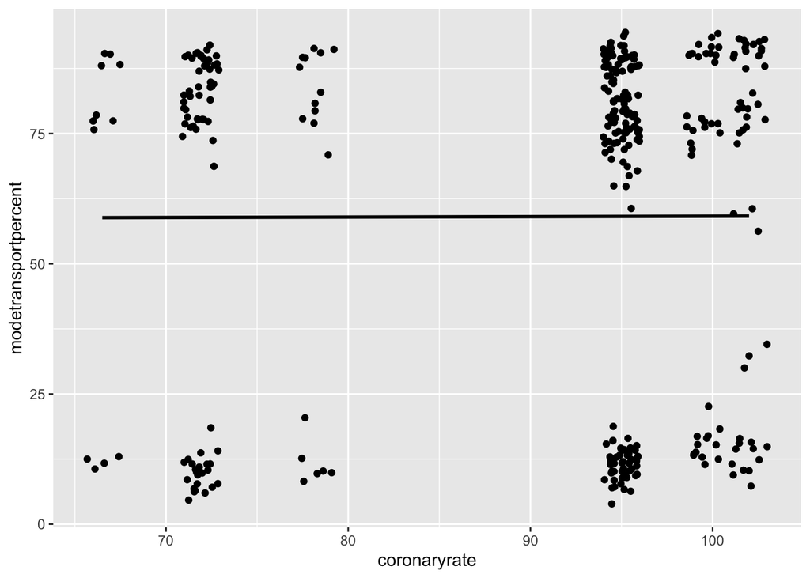

```r
plots <- transhealth %>%
  filter(!is.na(modetransportpercent) & !is.na(coronaryrate) & !is.na(coronary) & modenew == "car")
plots %>%
    ggplot(mapping = aes(x = coronaryrate, y = modetransportpercent)) +
  geom_point( position="jitter") +
  geom_smooth(method = lm, se = FALSE, col = "black")
```

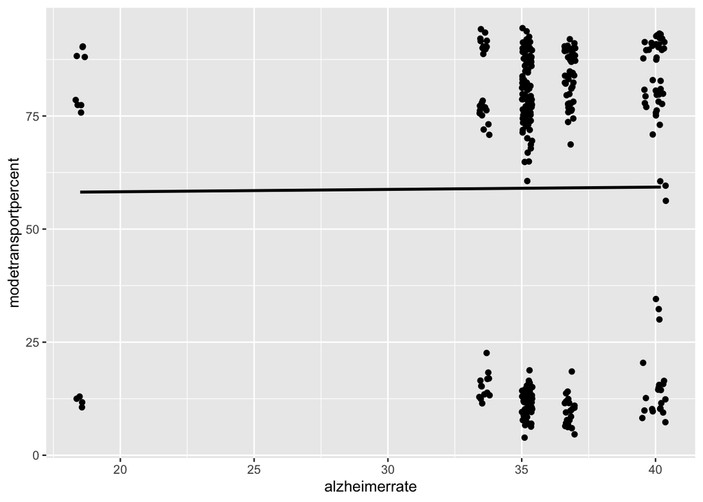

```r
plots <- transhealth %>%
  filter(!is.na(modetransportpercent) & !is.na(alzheimerrate) & !is.na(coronary) & modenew == "car")
plots %>%
    ggplot(mapping = aes(x = alzheimerrate, y = modetransportpercent)) +
  geom_point( position="jitter") +
  geom_smooth(method = lm, se = FALSE, col = "black")
```

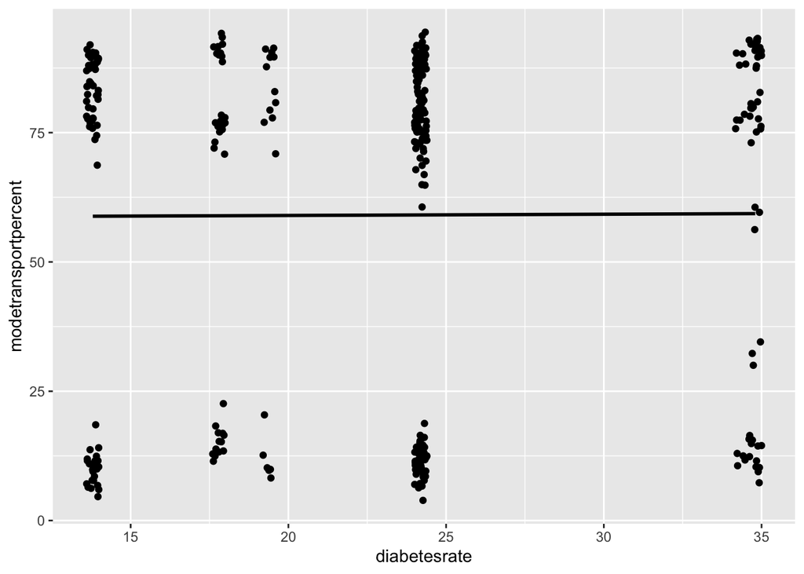

```r
plots <- transhealth %>%
  filter(!is.na(modetransportpercent) & !is.na(diabetesrate) & !is.na(coronary) & modenew == "car")
plots %>%
    ggplot(mapping = aes(x = diabetesrate, y = modetransportpercent)) +
  geom_point( position="jitter") +
  geom_smooth(method = lm, se = FALSE, col = "black")
```

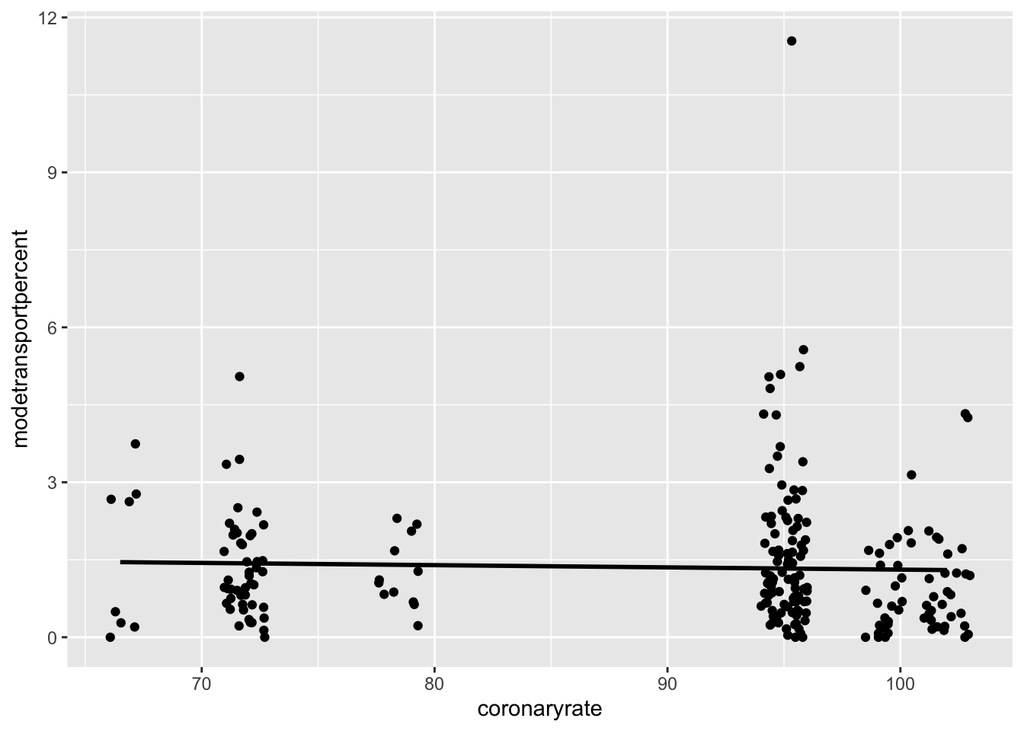

```r
plots <- transhealth %>%
  filter(!is.na(modetransportpercent) & !is.na(coronaryrate) & !is.na(coronary) & modenew == "physical")
plots %>%
    ggplot(mapping = aes(x = coronaryrate, y = modetransportpercent)) +
  geom_point( position="jitter") +
  geom_smooth(method = lm, se = FALSE, col = "black")
```

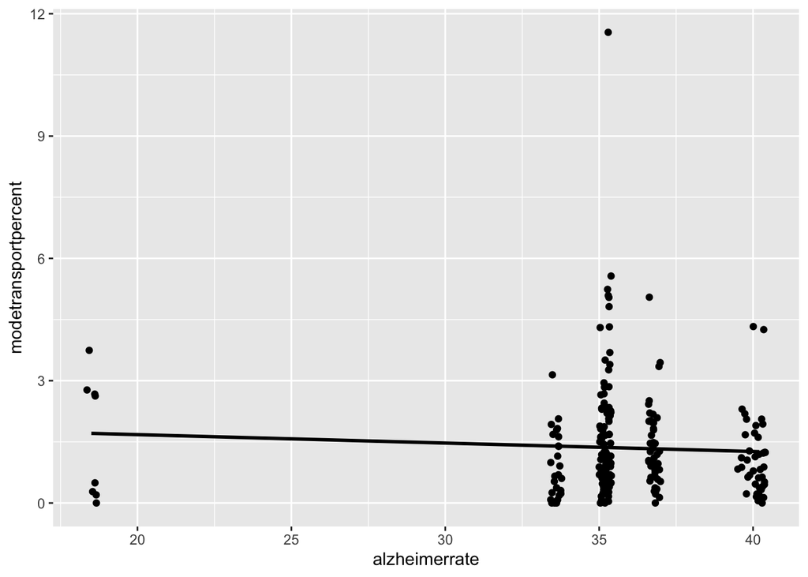

```r
plots <- transhealth %>%
  filter(!is.na(modetransportpercent) & !is.na(alzheimerrate) & !is.na(alzheimerrate) & modenew == "physical")
plots %>%
    ggplot(mapping = aes(x = alzheimerrate, y = modetransportpercent)) +
  geom_point( position="jitter") +
  geom_smooth(method = lm, se = FALSE, col = "black")
```

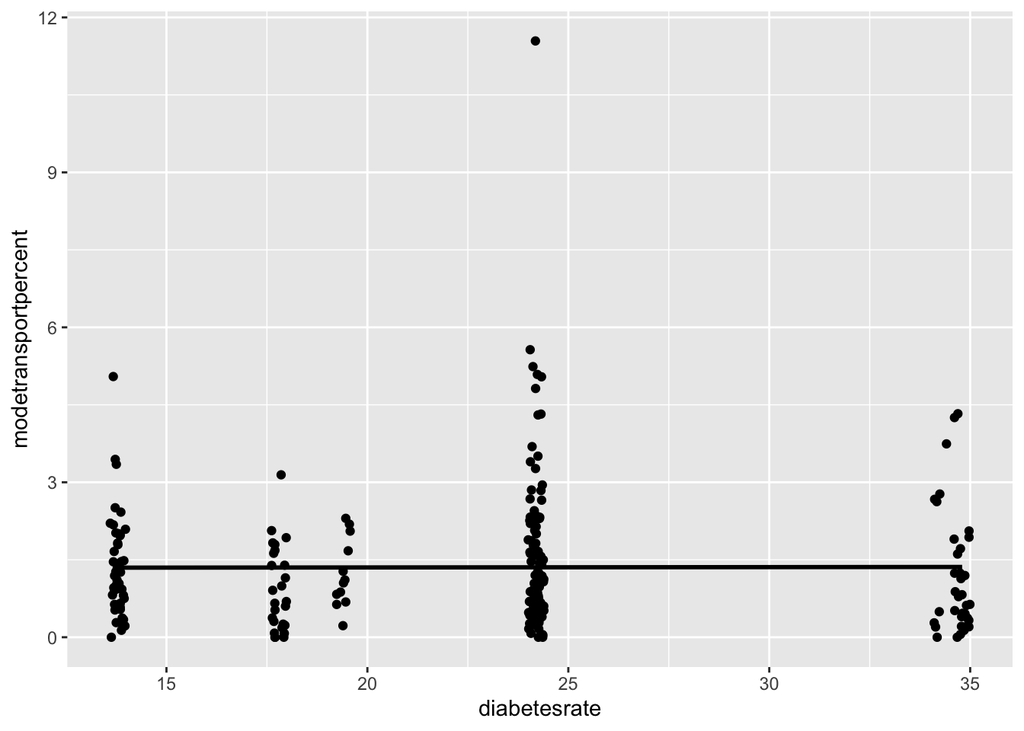

```r
plots <- transhealth %>%
  filter(!is.na(modetransportpercent) & !is.na(diabetesrate)  & modenew == "physical")
plots %>%
    ggplot(mapping = aes(x = diabetesrate, y = modetransportpercent)) +
  geom_point( position="jitter") +
  geom_smooth(method = lm, se = FALSE, col = "black")
```

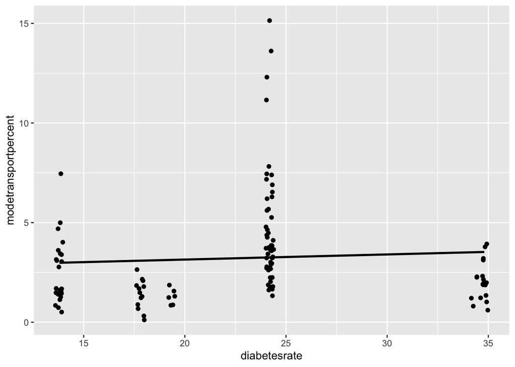

```r
plots <- transhealth %>%
  filter(!is.na(modetransportpercent) & !is.na(diabetesrate)  & modenew == "publictr")
plots %>%
    ggplot(mapping = aes(x = diabetesrate, y = modetransportpercent)) +
  geom_point( position="jitter") +
  geom_smooth(method = lm, se = FALSE, col = "black")
```

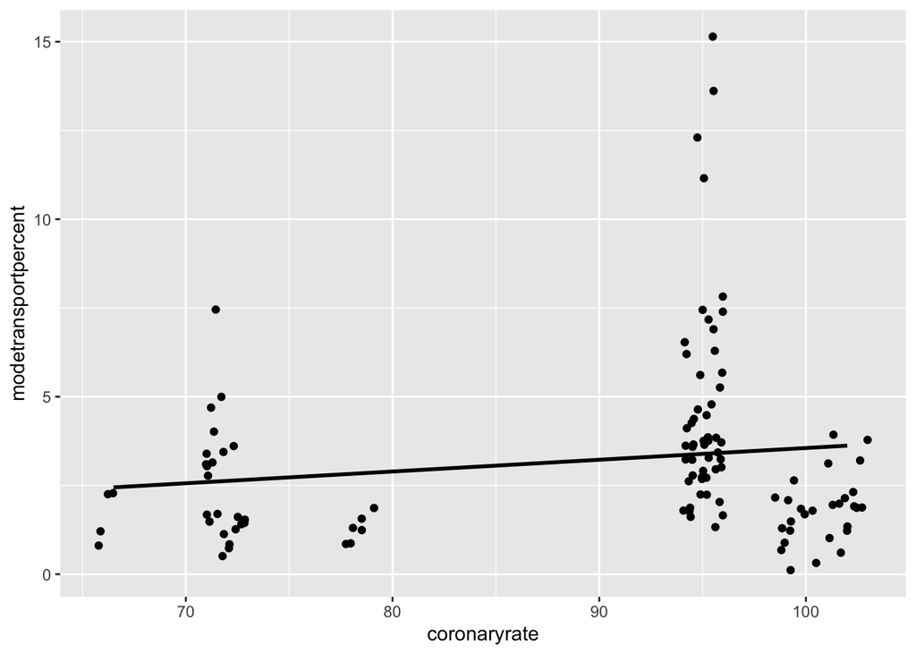

```r
plots <- transhealth %>%
  filter(!is.na(modetransportpercent) & !is.na(coronaryrate)  & modenew == "publictr")
plots %>%
    ggplot(mapping = aes(x = coronaryrate, y = modetransportpercent)) +
  geom_point( position="jitter") +
  geom_smooth(method = lm, se = FALSE, col = "black")
```

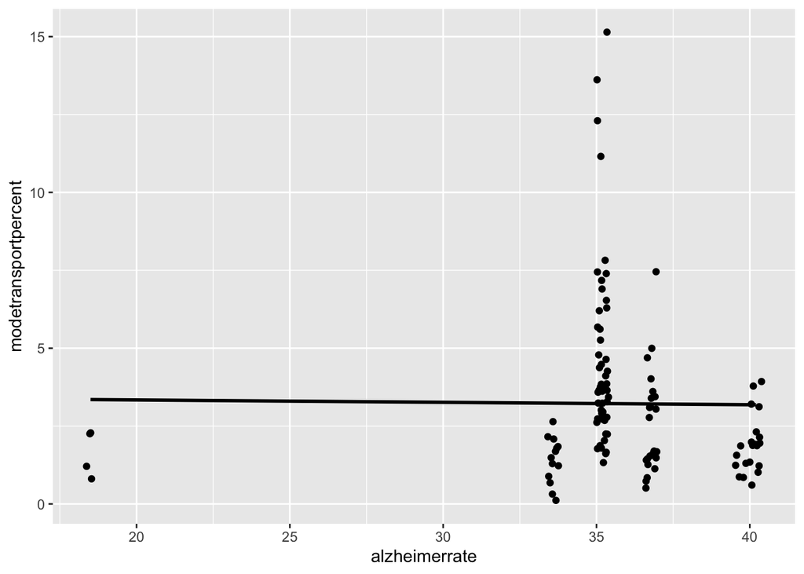

```r
plots <- transhealth %>%
  filter(!is.na(modetransportpercent) & !is.na(alzheimerrate)  & modenew == "publictr")
plots %>%
    ggplot(mapping = aes(x = alzheimerrate, y = modetransportpercent)) +
  geom_point( position="jitter") +
  geom_smooth(method = lm, se = FALSE, col = "black")
```

For a broader scale investigation of health for each county, rankings were assessed by modes of transportation. From the graph, counties with greater use of cars seemed to have the highest rankings, then physical commuting, then at home work and public transportation tied with the lowest rankings.

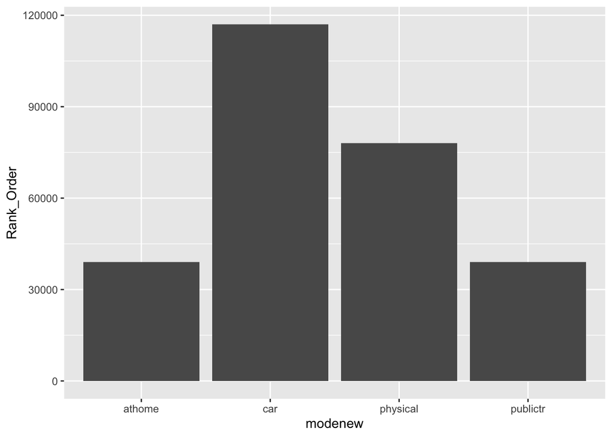

```r
plots <- transhealth %>%
  filter(!is.na(modenew) & !is.na(Rank_Order))
ggplot(plots, aes(x=modenew, y= Rank_Order)) +
     geom_bar(stat='identity') +
scale_fill_brewer(palette = "Dark2")
```

In the final step of analysis, I wanted to test whether location had any impact on health indicators and could potentially influence the association between health indicators and types of transportation. In general, it seems that Orange, Riverside, and Imperial counties all have higher rankings than other counties in Southern California, of which could potentially interfere with investigations.

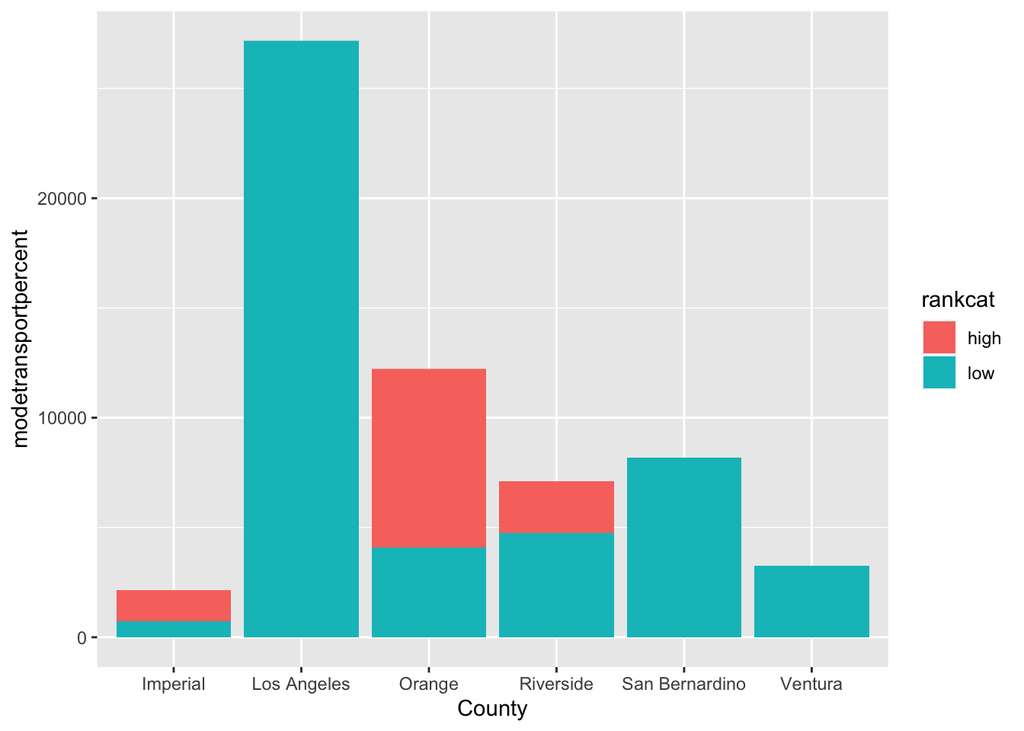

```r
plots <- transhealth %>%
  filter(!is.na(modetransportpercent) & !is.na(County) & modenew=="car")
ggplot(plots, aes(x=County, y= modetransportpercent, fill= rankcat)) +
     geom_bar(stat='identity')
```

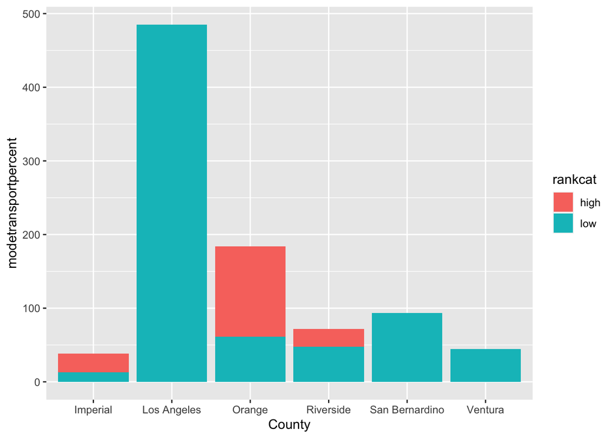

```r
plots <- transhealth %>%
  filter(!is.na(modetransportpercent) & !is.na(County) & modenew=="physical")
ggplot(plots, aes(x=County, y= modetransportpercent, fill= rankcat)) +
     geom_bar(stat='identity')
```

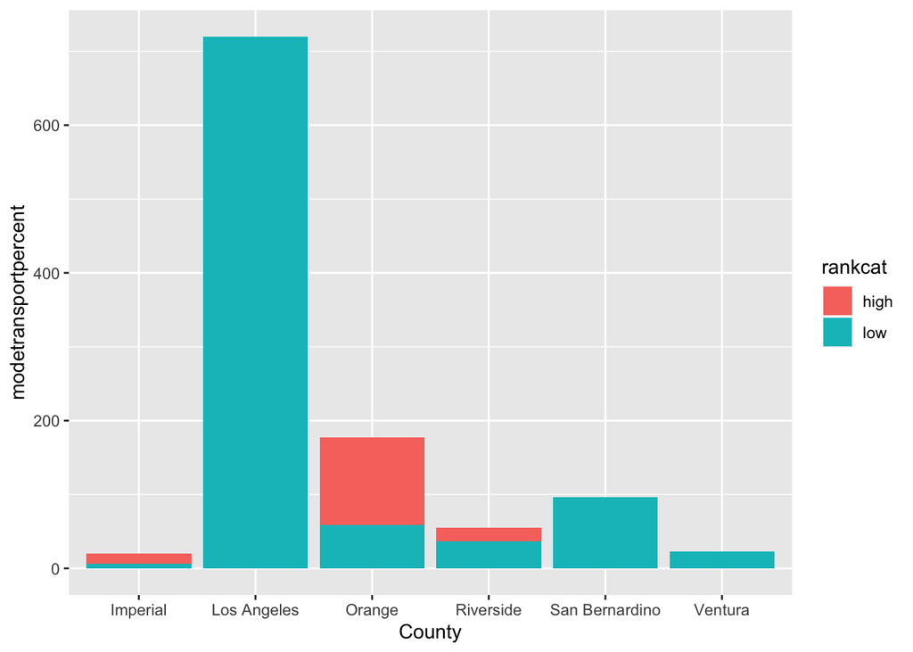

```r
plots <- transhealth %>%
  filter(!is.na(modetransportpercent) & !is.na(County) & modenew=="publictr")
ggplot(plots, aes(x=County, y= modetransportpercent, fill= rankcat)) +
     geom_bar(stat='identity')
```